# Simulating Policy Scenarios using Aggregate Model

Abhinav Saxena

```r
knitr::opts_chunk$set(echo = TRUE)
library(aggregate.model)
library(dplyr)
```

```r
library(purrr)
library(ggplot2)
```

# Simulating Policy Scenarios using Aggregate Model

## Applying the Aggregate Model to Real World Scenarios

While tackling the economic policy aspects of climate change, policymakers are required to take certain steps or announce policy measures that aim at reducing emissions from a particular economic activity. These policy measures can include announcing subsidies, tax breaks, investments in the activities that promote an environment-friendly outlook to the activity. On the other hand, the activities that are carbon-intensive and have a high environmental impact need to be reduced or completely abandoned as there is no more capacity for the planet to accommodate more emissions. The relevant policy measures in this case can be quantity limits, taxing the activity (or raising the tax), and in some cases even cutting off the activity.

In this vignette, I will simulate some of these policy scenarios using the Aggregate Model and will try to calculate the trajectory of emissions and the savings in emissions if these were to be exogenously pushed by the policymakers.

### Policy Scenario 1 : Metal Production in Germany

Germany is the biggest producer of Metals in the European Union and is one of the top producers in the world markets too. Metal Production is also one of the most energy and emissions intensive economic activities.

In this scenario, I will simulate the effect of a policy proposal that aims at cutting metal production in Germany to 50% of its 2015 values by 2027, as part of its commitments to an international climate agreement.

```r
dict_de <- dict %>%
  mutate(geo = "DE")
```

#### Adding Variables to the Dictionary

Once the dictionary is modified for our desired country, we can start by adding some variables that may be important for our analysis. In this case, I have selected the Index of Metal Production, Index of Industrial Production, and the Index of Plastic Production in Germany where the 2015 production value is set as a reference/index value of 100.

```r
dict_de <- dict_de %>%
  bind_rows(tibble(
  model_varname = "Metal_Prod",
  full_name = "Index of Manufacture of basic metals and fabricated metal products",
  database  = "eurostat",
  variable_code = "PROD",
  dataset_id = "sts_inpr_q",
  var_col = "indic_bt",
  freq = "q",
  geo = "DE",
  unit = "I15",
  s_adj = "NSA",
  nace_r2 = "C24_C25"))

dict_de <- dict_de %>%
  bind_rows(tibble(
    model_varname = "Ind_Prod",
    full_name = "An index of Industrial Production",
    database  = "eurostat",
    variable_code = "PROD",
    dataset_id = "sts_inpr_q",
    var_col = "indic_bt",
    freq = "q",
    geo = "DE",
    unit = "I15",
    s_adj = "NSA",
    nace_r2 = "B-D"))

dict_de <- dict_de %>%
  bind_rows(tibble(
    model_varname = "PlaProd",
    full_name = "An index of Plastic Production",
    database  = "eurostat",
    variable_code = "PROD",
    dataset_id = "sts_inpr_q",
    var_col = "indic_bt",
    freq = "q",
    geo = "DE",
    unit = "I15",
    s_adj = "NSA",
    nace_r2 = "C222"))
```

#### Specification

For this particular illustrative scenario, we have used a three equation specification of the model:

```r
specification <- dplyr::tibble(
  type = c(
    "n",
    "n",
    "n"
  ),
  dependent = c(
    "Ind_Prod",
    "EmiCO2Industry",
    "EmiCO2Combustion"
  ),
  independent = c(
    "Metal_Prod + PlaProd + Import",
    "HICP_Energy + Metal_Prod + Export",
    "FinConsExpHH + HICP_Gas + EmiCO2Industry + Ind_Prod"
    )
)
specification
```

```
#> # A tibble: 3 × 3
#>   type  dependent        independent
#>   <chr> <chr>            <chr>
#> 1 n     Ind_Prod         Metal_Prod + PlaProd + Import
#> 2 n     EmiCO2Industry   HICP_Energy + Metal_Prod + Export
#> 3 n     EmiCO2Combustion FinConsExpHH + HICP_Gas + EmiCO2Industry + Ind_Prod
```

In this specification, we have modelled Industrial Production, Industrial Emissions, and Emissions from Combustion. For these different dependent variables, there are a set of independent variables that have been used. But in this simulation, we are most concerned with the effect of Metal_Prod on EmiCO2Industry.

#### Running the Model

We are now ready to run the model. We have created a new folder called metal where the fetched data (data_metal) would be saved and this locally saved data would be used to run the model in subsequent iterations.

```r
model <- run_model(specification = specification,
                   dictionary = dict_de,
                   inputdata_directory = "/Users/abhinavsaxena/aggregate.model/data-raw/metal/",
                   primary_source = "local",
                   save_to_disk =
                   "/Users/abhinavsaxena/aggregate.model/data-raw/metal/data_metal.xlsx",
                   saturation.tpval = 0.001,
                   max.ar = 2,
                   max.dl = 2,
                   quiet = FALSE,
                   saturation = NULL,
                   constrain.to.minimum.sample = FALSE)
```

```
#> Local files are used.
#> The following files are opened and scanned for relevant data for the model.
#> data_metal.xlsx
#> Note: If these include non-data files (with a likely different structure and hence likely errors), it is recommended to move all data files to a dedicated directory or to save them there using the 'save_to_disk' argument in the first place:
#>
#> You can quiet this message with quiet = TRUE.
#>
#> --- Estimation begins ---
#> Estimating Ind_Prod = Metal_Prod + PlaProd + Import
#> Warning in gets::arx(y = yvar, mxreg = as.matrix(xvars), ar = if (i != 0) {:
#>
#> New default 'mc = TRUE' in arx() as of version 0.28
#> This warning only appears the first time arx() is invoked
#> To suppress this warning, set options(mc.warning = FALSE)
#> Estimating EmiCO2Industry = HICP_Energy + Metal_Prod + Export
#> Estimating EmiCO2Combustion = FinConsExpHH + HICP_Gas + EmiCO2Industry + Ind_Prod
```

#### Evaluating the Model

Now, we can have a look at the model summary. As we can see, the coefficient of Metal Production is statistically significant at a significance level of 0.001, thereby indicating a strong positive relationship between Industrial CO2 Emissions and Metal Production in Germany.

```r
library(modelsummary)

class(model)
```

```
#> [1] "aggmod"
```

```r
model_list <- lapply(model$module_collection$model, gets::as.lm)
names(model_list) <- model$module_order$dependent
modelsummary::modelsummary(
  model_list,
  coef_omit = "iis|sis",
  gof_omit = "R",
  notes = "Impulse (IIS) and Step Indicators (SIS) are not shown individually but were activated for all models.",
  stars = TRUE
)
```

|  | Ind_Prod | EmiCO2Industry | EmiCO2Combustion |
| --- | --- | --- | --- |
| trend | −0.001*** |  | −0.004*** |
|  | (0.000) |  | (0.001) |
| ln.Metal_Prod | 0.441*** | 1.812*** |  |
|  | (0.039) | (0.122) |  |
| ln.PlaProd | 0.264*** |  |  |
|  | (0.038) |  |  |
| ln.Import | 0.107** |  |  |
|  | (0.037) |  |  |
| L1.ln.Import | 0.001 |  |  |
|  | (0.036) |  |  |
| L1.ln.Metal_Prod | 0.117** |  |  |
|  | (0.037) |  |  |
| L1.ln.PlaProd | −0.104** |  |  |
|  | (0.035) |  |  |
| q_2 | −0.008*** | −0.155*** | −0.495*** |
|  | (0.002) | (0.030) | (0.024) |
| q_3 | −0.010*** | −0.312*** | −0.473*** |
|  | (0.002) | (0.030) | (0.020) |
| q_4 | 0.042*** | −0.077* |  |
|  | (0.003) | (0.030) |  |
| ln.HICP_Energy |  | 0.300** |  |
|  |  | (0.104) |  |
| L1.ln.Ind_Prod |  |  | 0.777*** |
|  |  |  | (0.146) |
| L1.ln.EmiCO2Industry |  |  | 1.025*** |
|  |  |  | (0.064) |
| Num.Obs. | 131 | 108 | 127 |
| AIC | −886.2 | −159.7 | −249.5 |
| BIC | −831.6 | −132.9 | −226.7 |
| Log.Lik. | 462.109 | 89.853 | 132.730 |

+ p < 0.1, * p < 0.05, ** p < 0.01, *** p < 0.001  
Impulse (IIS) and Step Indicators (SIS) are not shown individually but were activated for all models.

##### Module Network

We can show the relationship between the different modules using the `network()` function.

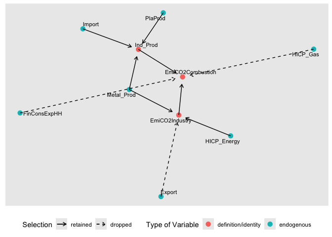

```r
network(model)
```

Each node represents a module and the different colours represent whether the variable is given by a definition/identity, whether it has been modelled as an endogenous variable depending on other models, and whether it is an exogenous variable input to the models.

An solid line arrow means that the variable has been retained during model selection, while a dashed arrow means that the variable has been found insignificant and thus dropped during model selection.

#### Forecasting (Simulating Policy Scenarios)

Now, this is where we can simulate policy scenarios based on the forecasted values of variables we are interested in. Firstly, we can use the forecast_model() function to forecast values of the different modules using an autoregressive (AR) function and save the results. Since, in this scenario assumption, we have 15 quarters to model we have set the parameter n.ahead=15.

```r
f1 <- forecast_model(model, exog_fill_method = "AR", n.ahead = 15, plot.forecast = FALSE)
```

```
#> No exogenous values provided. Model will forecast the exogenous values with an AR4 process (incl. Q dummies, IIS and SIS w 't.pval = 0.001').
#> Alternative is exog_fill_method = 'last'.
```

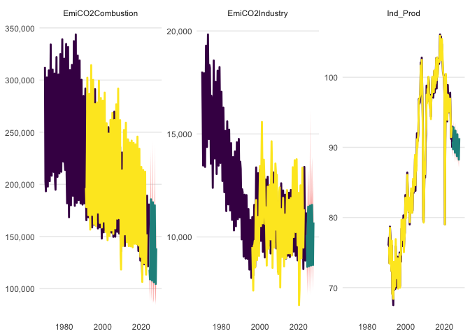

```r
plot(f1)
```

The following code is crucial for this scenario assumption. We have assumed that the cuts in production will progress over the quarters at a constant rate. To calculate this rate and therefore the indexed quantity of metal production, we have used a simple compounding formula which estimates a rate of 3.76% decline per quarter. In simple terms, the production of each subsequent quarter will be 3.76% less than the preceding quarter so that it finally reaches to 50% (of 2015) by the last quarter of 2027. It can be noted that this is only one way to reach this goal.

```r
initial_value <- f1$exog_data_nowcast$Metal_Prod[1]
final_value <- 50 #Final Value is the desired policy implementation. That by 2027, the metal production should be 60% of that of the 2015 value.
periods <- 16

rate <- (final_value / initial_value)^(1 / (periods - 1)) #In this case, this requires cutting the metal production by around 3.76% of the previous quarter

decreasing_values <- initial_value * rate^(0:(periods - 1))
```

Now we can apply these calculated values as exogenously provided values to forecast another model with these lower values of metal production to calculate savings in industrial emissions.

```r
exog_data_high_ready <- f1$exog_data_nowcast %>%
  mutate(Metal_Prod = decreasing_values)

f1_high <- forecast_model(model, exog_predictions = exog_data_high_ready, plot.forecast = FALSE)
```

From this forecast, we can easily retain the data of two variables we are interested in, namely Industrial Emissions and Metal Production. The grepl_variables parameter in the plot() function matches the string combination to automatically capture the desired variable without the need of writing the exact variable name as it is saved. We can use this data to create a plot to visually present our forecast results of these variables under the exogenously provided metal production quantities.

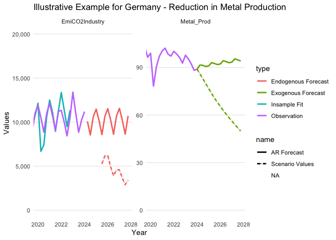

```r
f1_data <- plot(f1, exclude.exogenous = FALSE, grepl_variables = "Industry|Metal", return.data = TRUE)
f1_high_data <- plot(f1_high, exclude.exogenous = FALSE, grepl_variables = "Industry|Metal", return.data = TRUE)

plotting_scenario_data <- f1_data %>%
  mutate(name = "AR Forecast") %>%
  bind_rows(f1_high_data %>%
              mutate(name = NA) %>%
              mutate(name = case_when(na_item == "EmiCO2Industry" & type == "Endogenous Forecast" ~
              "Scenario Values",
              na_item == "Metal_Prod" & type == "Exogenous Forecast" ~ "Scenario Values",
              TRUE ~ name)))

plotting_scenario_data %>%
  ggplot(aes(x = time, y = values, linetype = name, color = type)) +
  geom_line() +
  coord_cartesian(xlim = c(as.Date("2020-01-01"),as.Date("2027-10-01"))) +
  facet_wrap(~na_item, scales = "free") +
  geom_line(linewidth = 1, na.rm = TRUE) +
  facet_wrap(~.data$na_item, scales = "free") +
  labs(x = "Year", y = "Values") +
  scale_y_continuous(labels = scales::label_comma(), limits = c(0, NA)) +
  theme_minimal() +
  theme(panel.grid.major.x = element_blank(),
        panel.grid.minor.x = element_blank(),
        panel.grid.minor.y = element_blank())+
  labs(title = "Illustrative Example for Germany - Reduction in Metal Production")
```

Finally calculating the savings in emissions. It can be noted a positive diff indicates the rise in emissions given the scenario values whereas a negative diff value suggests a fall in emissions under the scenario. In this case, we observe a very high diff of 106714 units between the AR forecasted values of metal production and those given exogenously.

```r
f1_data %>%
  mutate(name = "AR Forecast") %>%
  bind_rows(f1_high_data %>%
              mutate(name = "Scenario Values")) %>%
  filter(na_item == "EmiCO2Industry" & type == "Endogenous Forecast") %>%
  summarise(emissions = sum(values, na.rm = TRUE), .by = name) %>%
  mutate(total = sum(emissions),
         diff = c(NA,diff(emissions)),
         rel_diff = diff/total)
```

```
#> # A tibble: 2 × 5
#>   name            emissions   total     diff rel_diff
#>   <chr>               <dbl>   <dbl>    <dbl>    <dbl>
#> 1 AR Forecast       152333. 197952.      NA    NA
#> 2 Scenario Values    45619. 197952. -106714.   -0.539
```

#### Shiny App

We can also get an overview and summary of the whole aggregate model results in a Shiny app, which can be opened using the`present_model()` command. The following code snippet is not executed:

```r
present_model(model)
```

### Policy Scenario 2 : Energy Subsidies in Austria

In this scenario, a policy proposal that aims to subsidise energy prices in Austria is considered. This move has been a popular strategy for governments, during the times of high energy prices, to relieve households and businesses from high prices. Conversely, it has significant implications for GHG emissions.

#### Adding Variables to the Dictionary

In this simulation, I have added only one model to our pre-exisiting dictionary (dict) on Industrial Production.

```r
new_dict <- dict %>%
  bind_rows(tibble(
    model_varname = "IndProd",
    full_name = "An index of Industrial Production",
    database  = "eurostat",
    variable_code = "PROD",
    dataset_id = "sts_inpr_q",
    var_col = "indic_bt",
    freq = "q",
    geo = "AT",
    unit = "I15",
    s_adj = "NSA",
    nace_r2 = "B-D"))
```

#### Specification

For this particular scenario, a three equation specification of the model has been used:

```r
spec <- dplyr::tibble(
  type = c(
    "n",
    "n",
    "n"
  ),
  dependent = c(
    "EmiCO2Industry",
    "EmiCO2Combustion",
    "FinConsExpHH"
  ),
  independent = c(
    "HICP_Energy + IndProd + Export",
    "FinConsExpHH + HICP_Energy",
    "FinConsExpGov + HICP_Energy"
  )
)
spec
```

```
#> # A tibble: 3 × 3
#>   type  dependent        independent
#>   <chr> <chr>            <chr>
#> 1 n     EmiCO2Industry   HICP_Energy + IndProd + Export
#> 2 n     EmiCO2Combustion FinConsExpHH + HICP_Energy
#> 3 n     FinConsExpHH     FinConsExpGov + HICP_Energy
```

In this specification, I have modelled Industrial Emissions, Emissions from Combustion, and Household Consumption Expenditure. For these different dependent variables, certain variables such as Energy Prices (HICP_Energy), Industrial Production Index, Exports, etc. have been used. But in this simulation, we are most concerned with the effect of HICP_Energy on Emissions from Combustion.

#### Running the Model

To avoid using saved data for other models, I have created a new folder titled “Your_Folder” where the data for this particular model can be saved and used in the further iterations of this model.

```r
model2 <- run_model(specification = spec,
                   dictionary = new_dict,
                   inputdata_directory = "/Users/abhinavsaxena/aggregate.model/data-raw/your_folder/",
                   primary_source = "local",
                   save_to_disk =
                   "/Users/abhinavsaxena/aggregate.model/data-raw/your_folder/data_new.xlsx",
                   saturation.tpval = 0.001,
                   max.ar = 2,
                   max.dl = 2,
                   quiet = FALSE,
                   saturation = NULL,
                   constrain.to.minimum.sample = FALSE)
```

```
#> Local files are used.
#> The following files are opened and scanned for relevant data for the model.
#> data_new.xlsx
#> Note: If these include non-data files (with a likely different structure and hence likely errors), it is recommended to move all data files to a dedicated directory or to save them there using the 'save_to_disk' argument in the first place:
#>
#> You can quiet this message with quiet = TRUE.
#>
#> --- Estimation begins ---
#> Estimating EmiCO2Industry = HICP_Energy + IndProd + Export
#> Estimating FinConsExpHH = FinConsExpGov + HICP_Energy
#> Estimating EmiCO2Combustion = FinConsExpHH + HICP_Energy
```

#### Evaluating the Model

```r
library(modelsummary)

model_list2 <- lapply(model2$module_collection$model, gets::as.lm)
names(model_list2) <- model2$module_order$dependent
modelsummary::modelsummary(
  model_list2,
  gof_omit = "R",
  title = "Models run for each sub-module for this illustrative example of Austria.",
  stars = TRUE
)
```

Models run for each sub-module for this illustrative example of Austria.

|  | EmiCO2Industry | FinConsExpHH | EmiCO2Combustion |
| --- | --- | --- | --- |
| trend | −0.006*** |  |  |
|  | (0.000) |  |  |
| ln.Export | 0.797*** |  |  |
|  | (0.002) |  |  |
| q_2 | −0.131*** |  |  |
|  | (0.007) |  |  |
| q_3 | −0.310*** |  |  |
|  | (0.007) |  |  |
| q_4 | −0.093*** |  |  |
|  | (0.007) |  |  |
| iis202 | 0.105*** |  |  |
|  | (0.029) |  |  |
| sis113 | −0.091*** |  |  |
|  | (0.010) |  |  |
| sis182 | 0.054*** |  |  |
|  | (0.010) |  |  |
| sis202 | 0.038** |  |  |
|  | (0.012) |  |  |
| sis209 | −0.105*** |  |  |
|  | (0.017) |  |  |
| sis102 |  | 10.457*** |  |
|  |  | (0.089) |  |
| sis2 |  |  | 9.570*** |
|  |  |  | (0.048) |
| Num.Obs. | 112 | 116 | 212 |
| AIC | −487.2 | 322.6 | 452.6 |
| BIC | −457.3 | 328.1 | 459.3 |
| Log.Lik. | 254.590 | −159.288 | −224.305 |

+ p < 0.1, * p < 0.05, ** p < 0.01, *** p < 0.001

##### Module Network

We can show the relationship between the different modules using the `network()` function.

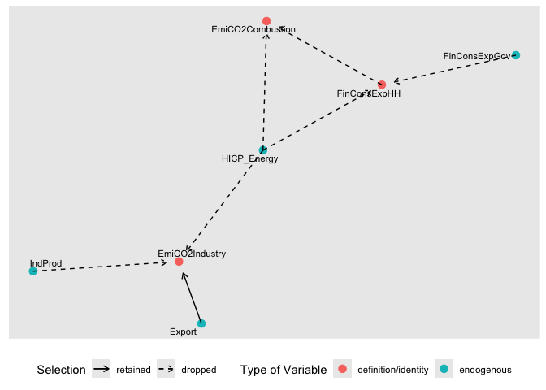

```r
network(model2)
```

Each node represents a module and the different colours represent whether the variable is given by a definition/identity, whether it has been modelled as an endogenous variable depending on other models, and whether it is an exogenous variable input to the models.

An solid line arrow means that the variable has been retained during model selection, while a dashed arrow means that the variable has been found insignificant and thus dropped during model selection.

#### Forecasting (Simulating Policy Scenarios)

In this scenario assumption, we are forecasting the energy prices for 10 quarters and would apply a 15% price cut owing to subsidies as compared to the forecasted values.

```r
f2 <- forecast_model(model2, exog_fill_method = "AR", plot.forecast = FALSE)
```

```
#> No exogenous values provided. Model will forecast the exogenous values with an AR4 process (incl. Q dummies, IIS and SIS w 't.pval = 0.001').
#> Alternative is exog_fill_method = 'last'.
```

Now we can apply these calculated values as exogenously provided values to forecast another model with lower energy prices.

```r
exog_data_low <- f2$exog_data_nowcast %>%
  mutate(HICP_Energy = 0.85*HICP_Energy)
f2_low <- forecast_model(model2, exog_predictions = exog_data_low, plot.forecast = FALSE)
```

Now we will retain the data for our two desired variables, i.e., Emissions from Combustion and HICP_Energy. We can visualise the plot for the two scenarios as well.

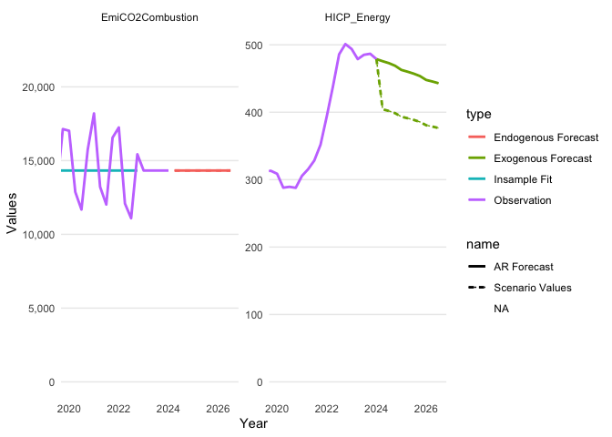

```r
f2_data <- plot(f2, exclude.exogenous = FALSE, grepl_variables = "Combustion|Energy", return.data = TRUE)

f2_low_data <- plot(f2_low, exclude.exogenous = FALSE, grepl_variables = "Combustion|Energy", return.data = TRUE)

plotting_scenario_data <- f2_data %>%
  mutate(name = "AR Forecast") %>%
  bind_rows(f2_low_data %>%
              mutate(name = NA) %>%
              mutate(name = case_when(na_item == "EmiCO2Combustion" & type == "Endogenous Forecast" ~ "Scenario Values",
                                      na_item == "HICP_Energy" & type == "Exogenous Forecast" ~ "Scenario Values",
                                      TRUE ~ name)))
plotting_scenario_data %>%
  ggplot(aes(x = time, y = values, linetype = name, color = type)) +
  geom_line() +
  coord_cartesian(xlim = c(as.Date("2020-01-01"),as.Date("2026-07-01"))) +
  facet_wrap(~na_item, scales = "free") +
  geom_line(linewidth = 1, na.rm = TRUE) +
  facet_wrap(~.data$na_item, scales = "free") +
  labs(x = "Year", y = "Values") +
  scale_y_continuous(labels = scales::label_comma(), limits = c(0, NA)) +
  theme_minimal() +
  theme(panel.grid.major.x = element_blank(),
        panel.grid.minor.x = element_blank(),
        panel.grid.minor.y = element_blank())
```

```r
f2_data %>%
  mutate(name = "AR Forecast") %>%
  bind_rows(f2_low_data %>%
              mutate(name = "Scenario Values")) %>%
  filter(na_item == "EmiCO2Combustion" & type == "Endogenous Forecast") %>%
  summarise(emissions = sum(values, na.rm = TRUE), .by = name) %>%
  mutate(total = sum(emissions),
         diff = c(NA,diff(emissions)),
         rel_diff = diff/total)
```

```
#> # A tibble: 2 × 5
#>   name            emissions   total  diff rel_diff
#>   <chr>               <dbl>   <dbl> <dbl>    <dbl>
#> 1 AR Forecast       143269. 286538.    NA       NA
#> 2 Scenario Values   143269. 286538.     0        0
```